# Terceiro trabalho prático de Introdução à Computação Visual:

Nome: Artur Gaspar da Silva Matrícula: 2020006388

# Instalando pacotes e baixando dados

```python
# Preparando dados:
!wget https://www.dropbox.com/s/itfqyh1trx9da7b/dados.zip
!unzip dados.zip
# Instalando bibliotecas:
!pip install tensorflow
!pip install keras
!pip install numpy
!pip install matplotlib
```

[output not shown]

[output cut: 4889 more lines]

[output not shown]

```python
import numpy as np
import os

from keras.models import Sequential, load_model
from keras.layers import Dense, Dropout, Activation, Flatten
from keras.layers.convolutional import Conv2D, MaxPooling2D
from keras.utils import np_utils
from keras.callbacks import ModelCheckpoint
from tensorflow.keras.utils import load_img

from matplotlib import pyplot as plt
%matplotlib inline

# Para reprodutibilidade
np.random.seed(13)
```

# Carregando imagens de treino e validação, além dos resultados esperados de todos Captchas

Nessa etapa, preparei as imagens e labels para serem treinadas pelo Keras.

```python
# Carregando labels (ground-truth)
all_labels = []
for name, dirs, files in os.walk("dados/CAPTCHA-10k/labels10k"):
  files = np.sort(files)
  for text_file in files:
    arq = open("dados/CAPTCHA-10k/labels10k/"+text_file)
    all_labels.append(arq.readlines()[0])
    arq.close()
all_labels = np.array(all_labels)

# Carregando treinamento
X_train_raw = []
for name, dirs, files in os.walk("dados/CAPTCHA-10k/treinamento"):
  files = np.sort(files)
  for image_file in files:
    img = load_img(
      "dados/CAPTCHA-10k/treinamento/"+image_file,
      color_mode="grayscale",
      target_size=None,
    )
    X_train_raw.append(np.array(img))
X_train_raw = np.array(X_train_raw)
y_train = all_labels[:8000]

# Carregando validacao
X_val_raw = []
for name, dirs, files in os.walk("dados/CAPTCHA-10k/validacao"):
  files = np.sort(files)
  for image_file in files:
    img = load_img(
      "dados/CAPTCHA-10k/validacao/"+image_file,
      color_mode="grayscale",
      target_size=None,
    )
    X_val_raw.append(np.array(img))
X_val_raw = np.array(X_val_raw)
y_val = all_labels[8000:9000]
```

Depois de varios testes, decidiu-se padronizar um padding em branco extra ao fim dos CAPTCHAS para termos todos caracteres com mesmo tamanho e centralizados de forma parecida.

```python
# Adicionando padding branco nos caracteres finais do traino e da validacao:
padding_trains = np.full((X_train_raw.shape[0],X_train_raw.shape[1],X_train_raw.shape[2]+6),255)
print(X_train_raw.shape)
padding_trains[:,:,:-6] = X_train_raw
print(padding_trains.shape)
X_train_raw = padding_trains

padding_vals = np.full((X_val_raw.shape[0],X_val_raw.shape[1],X_val_raw.shape[2]+6),255)
print(X_val_raw.shape)
padding_vals[:,:,:-6] = X_val_raw
print(padding_vals.shape)
X_val_raw = padding_vals
```

```
(8000, 50, 180)
(8000, 50, 186)
(1000, 50, 180)
(1000, 50, 186)
```

```
338
1BELYC
```

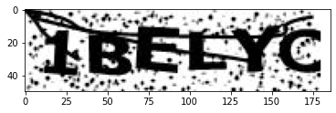

```python
# Visualizando uma imagem aleatoria do treinamento
num = np.random.randint(0,8000)
print(num)
print(y_train[num])
plt.imshow(X_train_raw[num], cmap="gray")
```

```
176
A47GBH
```

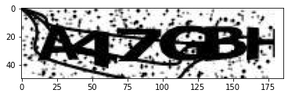

```python
# Visualizando uma imagem aleatoria da validacao
num = np.random.randint(0,1000)
print(num)
print(y_val[num])
plt.imshow(X_val_raw[num], cmap="gray")
```

```python
# Setando profundidade das imagens para 1
X_train = X_train_raw.reshape(X_train_raw.shape[0], 50, 186, 1)
X_val = X_val_raw.reshape(X_val_raw.shape[0], 50, 186, 1)
print(X_train.shape)
print(y_train.shape)
print(X_val.shape)
print(y_val.shape)
```

```
(8000, 50, 186, 1)
(8000,)
(1000, 50, 186, 1)
(1000,)
```

### Divisão dos caracteres

Percebeu-se (veja a seção "Tentativas Falhas") que o treinamento funciona muito melhor se for feito com os caracteres individuais ao invés de com os seis caracteres de uma vez. Portanto, é preciso a partir da imagem inicial separar os seis caracteres presentes, e escolhi fazer isso de forma manual: na base da tentativa e erro encontrar como separar adequadamente. É na célula abaixo que se especifica em que posições serão feitos os cortes que separam cada um dos 6 caracteres das imagens de entrada.

Note que essa etapa é provavelmente a que mais impacta no resultado final, pois dependendo de como se cortam os caracteres nem um humano é capaz de diferenciar um "C" de um "O" por exemplo (caso cortemos antes do finalzinho do caractere), ou um "V" de um "W" (caso cortemos antes da metade do W). Isso foi corroborado nas tentativas realizadas: nenhuma mudança na arquitetura da rede melhorou tanto o resultado quanto uma escolha melhor de onde separar os caracteres.

```python
# Setando onde cortaremos as imagens em caracteres:
dist = 3
ch_separation = [(10-dist,40+dist),(39-dist,69+dist),(70-dist,100+dist),(100-dist,130+dist),(128-dist,158+dist),(150,180+2*dist)]
```

```
74 0
(35, 36)
3
```

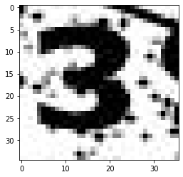

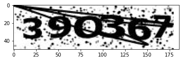

```python
# Pegando um caractere aleatorio do treinamento
num = np.random.randint(0,8000)
char = np.random.randint(0,6)
print(num, char)
print(X_train_raw[num][10:45,ch_separation[char][0]:ch_separation[char][1]].shape)
print(y_train[num][char])
plt.imshow(X_train_raw[num][10:45,ch_separation[char][0]:ch_separation[char][1]], cmap="gray")
plt.show()
plt.close()
plt.imshow(X_train_raw[num], cmap = "gray")
```

A etapa abaixo é importante pois caso não seja feita os pesos da rede se tornam cada vez maiores, prejudicando muito a qualidade do treino.

```python
# Normalizando imagens para ficar entre 0,1
X_train_norm = X_train.astype('float32')
X_val_norm = X_val.astype('float32')
X_train_norm /= 255
X_val_norm /= 255
```

Abaixo convencionei que os caracteres entre 0 e 9 são representados por números entre 0 e 9, e caracteres de letras são representadas pelos próximos números ("B" é o 11, "A" é 10, "Z" é 35, etc.)

```python
# Funcoes de conversao de caractere para numero inteiro em [0,36) e vice-versa
def char_to_num(ch):
  return ch-48 if ch < 65 else ch-65+10
def num_to_char(num):
  return chr(num+48) if num < 10 else chr(num+65-10)
```

Abaixo criei o treino e a validação, usando caracteres isolados ao invés de a imagem inteira.

```python
# Criando treino e validacao com caracteres isolados
X_train_isol_chars = []
y_train_isol_chars = []
for i in range(len(X_train_norm)):
  for char in [0,1,2,3,4,5]:
    X_train_isol_chars.append(X_train_norm[i][10:45,ch_separation[char][0]:ch_separation[char][1]])
    y_train_isol_chars.append(char_to_num(ord(y_train[i][char])))
X_train_isol_chars = np.array(X_train_isol_chars)
y_train_isol_chars = np.array(y_train_isol_chars)

X_val_isol_chars = []
y_val_isol_chars = []
for i in range(len(X_val_norm)):
  for char in [0,1,2,3,4,5]:
    X_val_isol_chars.append(X_val_norm[i][10:45,ch_separation[char][0]:ch_separation[char][1]])
    y_val_isol_chars.append(char_to_num(ord(y_val[i][char])))
X_val_isol_chars = np.array(X_val_isol_chars)
y_val_isol_chars = np.array(y_val_isol_chars)
```

Para treinar e avaliar no Keras, é preciso colocara o ground-truth em forma categórica: cada instância possui um vetor que possui um número 1 na posição do caractere correto para essa instância, e 0 na posição dos caracteres incorretos, segundo a numeração convencionada.

```python
# Categorizando letras
y_train_cat = np_utils.to_categorical(y_train_isol_chars, 36)
y_val_cat = np_utils.to_categorical(y_val_isol_chars, 36)
```

# Modelo final

Abaixo está o melhor modelo obtido, depois de várias tentativas (veja a seção "Tentativas Falhas"). Ele recebe um caractere e o classifica dentre os 36 possíveis. Utilizei três camadas convolucionais e três densas após "esticar" as features em vetor com Flatten(). Utilizei camadas de Dropout para evitar overfitting (pois o Dropout faz com que algumas das conexões sejam ignoradas durante um batch, de certa forma forçando que algo seja aprendido sobre os elementos da camada anterior).

```python
model = Sequential()
#CNN
model.add(Conv2D(32, (3, 3), strides=(1, 1), activation='relu', padding='same', input_shape=(35,30+2*dist,1)))

model.add(Conv2D(32, (3, 3), padding='same', activation='relu'))
model.add(Conv2D(32, (3, 3), padding='same', activation='relu'))
model.add(MaxPooling2D(pool_size=(2,2), padding='same'))
model.add(Dropout(0.25))

model.add(Flatten())
model.add(Dense(64, activation='relu'))
model.add(Dropout(0.25))
model.add(Dense(48, activation='relu'))
model.add(Dropout(0.25))
model.add(Dense(36, activation='softmax'))

model.summary()
```

```
Model: "sequential_7"
_________________________________________________________________
 Layer (type)                Output Shape              Param #
=================================================================
 conv2d_21 (Conv2D)          (None, 35, 36, 32)        320

 conv2d_22 (Conv2D)          (None, 35, 36, 32)        9248

 conv2d_23 (Conv2D)          (None, 35, 36, 32)        9248

 max_pooling2d_7 (MaxPooling  (None, 18, 18, 32)       0
 2D)

 dropout_21 (Dropout)        (None, 18, 18, 32)        0

 flatten_7 (Flatten)         (None, 10368)             0

 dense_21 (Dense)            (None, 64)                663616

 dropout_22 (Dropout)        (None, 64)                0

 dense_22 (Dense)            (None, 48)                3120

 dropout_23 (Dropout)        (None, 48)                0

 dense_23 (Dense)            (None, 36)                1764

=================================================================
Total params: 687,316
Trainable params: 687,316
Non-trainable params: 0
_________________________________________________________________
```

Utilizei a perda de entropia cruzada categórica, pois é uma das mais adequadas para nossos propósitos.

```python
model.compile(loss='categorical_crossentropy',
              optimizer='adam',
              metrics=['accuracy'])
```

O modelo treinado é salvo em arquivo para não ser preciso treiná-lo toda vez que formos abrir o notebook novamente (esse notebook foi criado no Google Colab versão gratuita, então depois que a sessão é encerrada o modelo é perdido se não for salvo e baixado).

```python
# Carregando o modelo caso ele ja tenha sido treinado e salvo:
if os.path.exists("1_tentativa"):
  model = load_model("1_tentativa")
else:
  model.fit(X_train_isol_chars, y_train_cat,
            batch_size=64, epochs=8, verbose=1, callbacks=[ModelCheckpoint(
                    filepath="1_tentativa",
                    verbose=1,save_best_only=False
                    )]
            )
```

```
Epoch 1: saving model to 1_tentativa
INFO:tensorflow:Assets written to: 1_tentativa/assets
Epoch 2: saving model to 1_tentativa
INFO:tensorflow:Assets written to: 1_tentativa/assets
Epoch 3: saving model to 1_tentativa
INFO:tensorflow:Assets written to: 1_tentativa/assets
Epoch 4: saving model to 1_tentativa
INFO:tensorflow:Assets written to: 1_tentativa/assets
Epoch 5: saving model to 1_tentativa
INFO:tensorflow:Assets written to: 1_tentativa/assets
Epoch 6: saving model to 1_tentativa
INFO:tensorflow:Assets written to: 1_tentativa/assets
Epoch 7: saving model to 1_tentativa
INFO:tensorflow:Assets written to: 1_tentativa/assets
Epoch 8: saving model to 1_tentativa
INFO:tensorflow:Assets written to: 1_tentativa/assets
```

Avaliando acuracia final do modelo para treino e validação:

```python
score = model.evaluate(X_val_isol_chars, y_val_cat, verbose=1)
print(score)
```

```
[0.10967816412448883, 0.9731666445732117]
```

```python
score = model.evaluate(X_train_isol_chars, y_train_cat, verbose=1)
print(score)
```

```
[0.07525450736284256, 0.9784791469573975]
```

```
33634
Esperado:   6
Obtido:     6
Com valor:  0.9998677
```

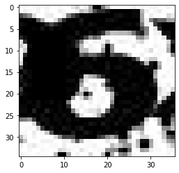

```python
# Pegando um caractere aleatorio do treinamento
num = np.random.randint(0,8000*6)
print(num)
print("Esperado:  ", num_to_char(y_train_isol_chars[num]))
pred = model.predict(X_train_isol_chars[num:num+1])
print("Obtido:    ", num_to_char(np.argmax(pred)))
print("Com valor: ", np.max(pred))
plt.imshow(X_train_isol_chars[num][:,:,0], cmap="gray")
```

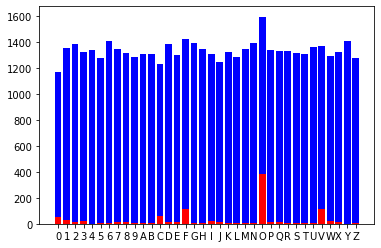

```python
# Dividindo treino entre os caracteres
X_train_div = [[] for i in range(36)]
for inst in range(len(X_train_isol_chars)):
  X_train_div[np.argmax(y_train_cat[inst])].append(X_train_isol_chars[inst])
for i in range(36):
  X_train_div[i] = np.array(X_train_div[i])
for i in range(36):
  plt.bar(num_to_char(i),len(X_train_div[i]), color = 'b')

incorrects = np.full(36,0)
for char in range(36):
  pred = model.predict(X_train_div[char])
  for val in range(len(pred)):
    incorrects[char] += np.argmax(pred[val]) != char
  plt.bar(char,incorrects[char], color = 'r')
plt.show()
```

O mesmo foi feito para validação. Note que aqui também temos mais erros nos caracteres "O", "C" e "0" também.

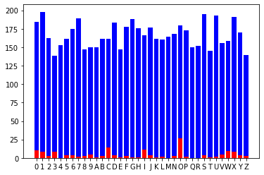

```python
# Dividindo validacao entre os caracteres
X_val_div = [[] for i in range(36)]
for inst in range(len(X_val_isol_chars)):
  X_val_div[np.argmax(y_val_cat[inst])].append(X_val_isol_chars[inst])
for i in range(36):
  X_val_div[i] = np.array(X_val_div[i])
for i in range(36):
  plt.bar(num_to_char(i),len(X_val_div[i]), color = 'b')

incorrects = np.full(36,0)
for char in range(36):
  pred = model.predict(X_val_div[char])
  for val in range(len(pred)):
    incorrects[char] += np.argmax(pred[val]) != char
  plt.bar(char,incorrects[char], color = 'r')
plt.show()
```

Plotareei também (dessa vez só para a validação), pra cada caractere correto, com quais caracteres ele foi mais confundido. Ou seja, o plot do caractere "O" indica por exemplo que na maioria das vezes a letra "O" é classificada corretamente, mas uma quantidade significativa de vezes é confundinda com "C".

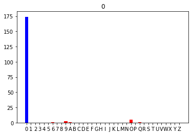

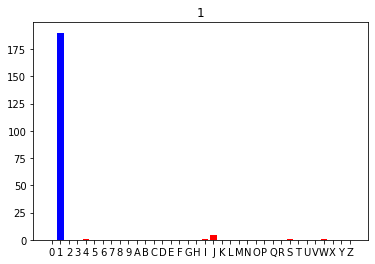

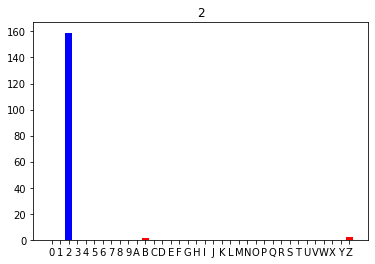

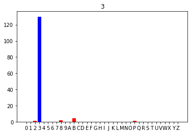

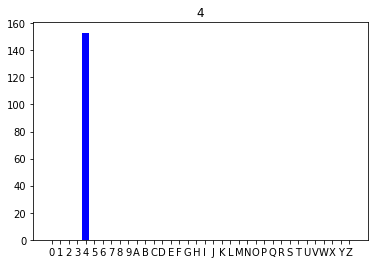

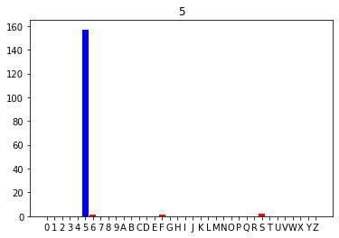

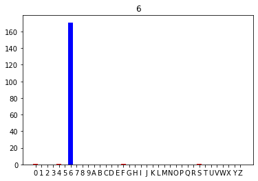

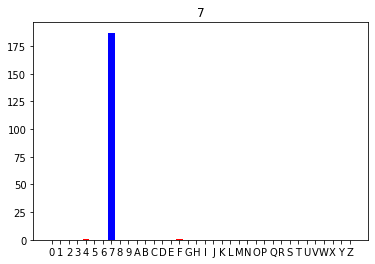

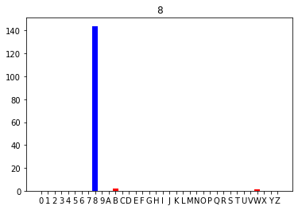

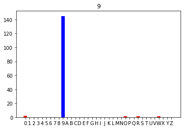

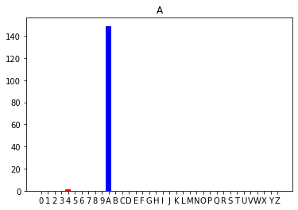

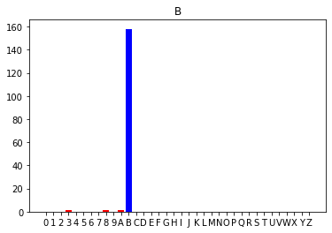

[24 more figures not shown]

```python
# Vendo com quais letras o modelo está confundindo as que deram mais erros:
# Um plot para cada caractere possivel 'x', com 36 valores de X e Y sendo quanto de
# cada letra deu, sendo que o caractere correto era 'x':

charn = [i for i in range(36)]

for jj in range(len(charn)):
  correct = charn[jj]
  amts = np.zeros(36)
  pred = model.predict(X_val_div[correct])
  for i in range(len(pred)):
    amts[np.argmax(pred[i])] += 1
  plt.close()
  plt.title(num_to_char(correct))
  colors = ['r' for j in range(36)]
  colors[correct] = 'b'
  plt.bar([num_to_char(j) for j in range(36)],amts, color = colors)
  plt.show()
```

Veja abaixo um caso que a letra "C" se parece muito (até mesmo para um humano) com "O":

```
18291
C
[0. 0. 0. 0. 0. 0. 0. 0. 0. 0. 0. 0. 1. 0. 0. 0. 0. 0. 0. 0. 0. 0. 0. 0.
 0. 0. 0. 0. 0. 0. 0. 0. 0. 0. 0. 0.]
```

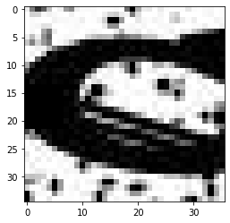

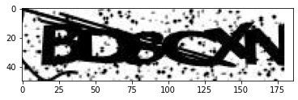

```python
# Pegando um caractere do treinamento
# 18291 -> C
num = 18291
print(num)
print(num_to_char(y_train_isol_chars[num]))
print(y_train_cat[num])
plt.imshow(X_train_isol_chars[num][:,:,0], cmap="gray")
plt.show()
plt.close()
plt.imshow(X_train_raw[num//6], cmap = "gray")
```

Abaixo temos um exemplo de letra cortada (letra M, ainda conseguimos identificar mas a letra completa não é vista):

```
20857
M
[0. 0. 0. 0. 0. 0. 0. 0. 0. 0. 0. 0. 0. 0. 0. 0. 0. 0. 0. 0. 0. 0. 1. 0.
 0. 0. 0. 0. 0. 0. 0. 0. 0. 0. 0. 0.]
```

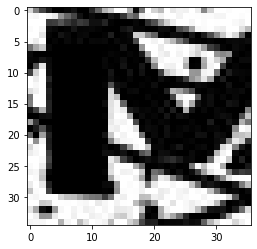

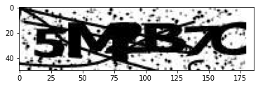

```python
# Pegando um caractere do treinamento
# 20857 -> M
num = 20857
print(num)
print(num_to_char(y_train_isol_chars[num]))
print(y_train_cat[num])
plt.imshow(X_train_isol_chars[num][:,:,0], cmap="gray")
plt.show()
plt.close()
plt.imshow(X_train_raw[num//6], cmap = "gray")
```

Por fim, abaixo temos quantos caracteres foram classificados corretamente de acordo com a posição do caractere no CAPTCHA:

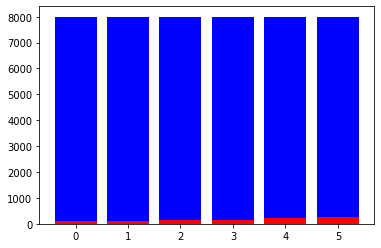

```python
# Verificando quais posicoes resultaram em mais erros:
for i in range(6):
  plt.bar(i,len(X_train_isol_chars[i::6]),color='b')

incorrects = np.full(6,0)
for pos in range(6):
  pred = model.predict(X_train_isol_chars[pos::6])
  for val in range(len(pred)):
    incorrects[pos] += np.argmax(pred[val]) != np.argmax(y_train_cat[pos::6][val])
  plt.bar(pos,incorrects[pos],color='r')
# plt.savefig("barras_pos_1_train.svg")
plt.show()
```

E visualizando somente os erros pra comparar (no treino primeiro):

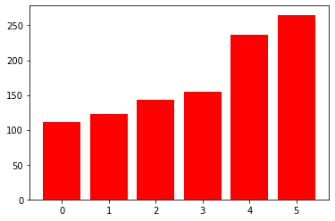

```
Erros de cada:  [111 123 143 155 236 265]
```

```python
incorrects = np.full(6,0)
for pos in range(6):
  pred = model.predict(X_train_isol_chars[pos::6])
  for val in range(len(pred)):
    incorrects[pos] += np.argmax(pred[val]) != np.argmax(y_train_cat[pos::6][val])
  plt.bar(pos,incorrects[pos],color='r')
# plt.savefig("barras_pos_1_train.svg")
plt.show()
print("Erros de cada: ", incorrects)
```

Agora na validação:

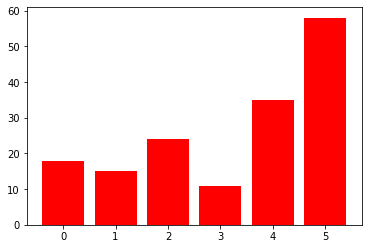

```
Erros de cada:  [18 15 24 11 35 58]
```

```python
incorrects = np.full(6,0)
for pos in range(6):
  pred = model.predict(X_val_isol_chars[pos::6])
  for val in range(len(pred)):
    incorrects[pos] += np.argmax(pred[val]) != np.argmax(y_val_cat[pos::6][val])
  plt.bar(pos,incorrects[pos],color='r')
# plt.savefig("barras_pos_1_val.svg")
plt.show()
print("Erros de cada: ", incorrects)
```